# MA3

Joe Littell

September 24, 2018

# **Methods and Analysis #3**

### **Birth weights and Smoking**

The Following analysis is utilizing a specified and cleaned dataset from the *Yerushalmy (1964, American Journal of Obstetrics and Gynecology)* Study.

```r
# Load needed libraries to analyize the data
library(tidyverse)
library(skimr)
library(lattice)

# Load the data itself
smoking <-read.csv("file:///C:/Users/Joseph/Documents/R/IDS 702/smoking.csv")

#look at the data
skim(smoking)
```

```
## Skim summary statistics
##  n obs: 869
##  n variables: 12
##
## -- Variable type:integer ---------------------------------------------------
##   variable missing complete   n    mean      sd   p0  p25  p50  p75 p100
##     bwt.oz       0      869 869  118.36   18.05   55  108  119  129  174
##       date       0      869 869 1536.42  106.95 1350 1444 1540 1627 1714
##  gestation       0      869 869  278.51   15.7   148  272  279  286  338
##         id       0      869 869 6032.42 2241.56   15 5477 6734 7587 9263
##        inc       0      869 869    3.68    2.28    0    2    3    5    9
##       mage       0      869 869   27.29    5.71   15   23   26   31   45
##        med       0      869 869    2.93    1.43    0    2    2    4    7
##        mht       0      869 869   64.07    2.53   53   62   64   66   72
##    mpregwt       0      869 869  128.48   20.78   87  113  125  140  220
##      mrace       0      869 869    3       3.11    0    0    2    7    9
##     parity       0      869 869    1.95    1.88    0    1    2    3   11
##      smoke       0      869 869    0.46    0.5     0    0    0    1    1
##      hist
##  ▁▁▂▅▇▃▁▁
##  ▆▇▇▆▇▆▆▇
##  ▁▁▁▁▁▇▂▁
##  ▁▁▂▁▂▆▇▂
##  ▇▆▆▅▅▂▅▂
##  ▁▆▇▆▃▃▂▁
##  ▁▃▇▁▅▃▁▁
##  ▁▁▂▅▆▇▁▁
##  ▂▇▇▃▂▁▁▁
##  ▇▁▁▁▂▁▃▁
##  ▇▃▃▁▁▁▁▁
##  ▇▁▁▁▁▁▁▇
```

```r
summary(smoking)
```

```
##        id            date        gestation         bwt.oz
##  Min.   :  15   Min.   :1350   Min.   :148.0   Min.   : 55.0
##  1st Qu.:5477   1st Qu.:1444   1st Qu.:272.0   1st Qu.:108.0
##  Median :6734   Median :1540   Median :279.0   Median :119.0
##  Mean   :6032   Mean   :1536   Mean   :278.5   Mean   :118.4
##  3rd Qu.:7587   3rd Qu.:1627   3rd Qu.:286.0   3rd Qu.:129.0
##  Max.   :9263   Max.   :1714   Max.   :338.0   Max.   :174.0
##      parity           mrace            mage            med
##  Min.   : 0.000   Min.   :0.000   Min.   :15.00   Min.   :0.000
##  1st Qu.: 1.000   1st Qu.:0.000   1st Qu.:23.00   1st Qu.:2.000
##  Median : 2.000   Median :2.000   Median :26.00   Median :2.000
##  Mean   : 1.953   Mean   :2.995   Mean   :27.29   Mean   :2.932
##  3rd Qu.: 3.000   3rd Qu.:7.000   3rd Qu.:31.00   3rd Qu.:4.000
##  Max.   :11.000   Max.   :9.000   Max.   :45.00   Max.   :7.000
##       mht           mpregwt           inc            smoke
##  Min.   :53.00   Min.   : 87.0   Min.   :0.000   Min.   :0.0000
##  1st Qu.:62.00   1st Qu.:113.0   1st Qu.:2.000   1st Qu.:0.0000
##  Median :64.00   Median :125.0   Median :3.000   Median :0.0000
##  Mean   :64.07   Mean   :128.5   Mean   :3.681   Mean   :0.4638
##  3rd Qu.:66.00   3rd Qu.:140.0   3rd Qu.:5.000   3rd Qu.:1.0000
##  Max.   :72.00   Max.   :220.0   Max.   :9.000   Max.   :1.0000
```

During the initial data analysis, nothing stood out about the cleaned data that could be detailed from simple summary information

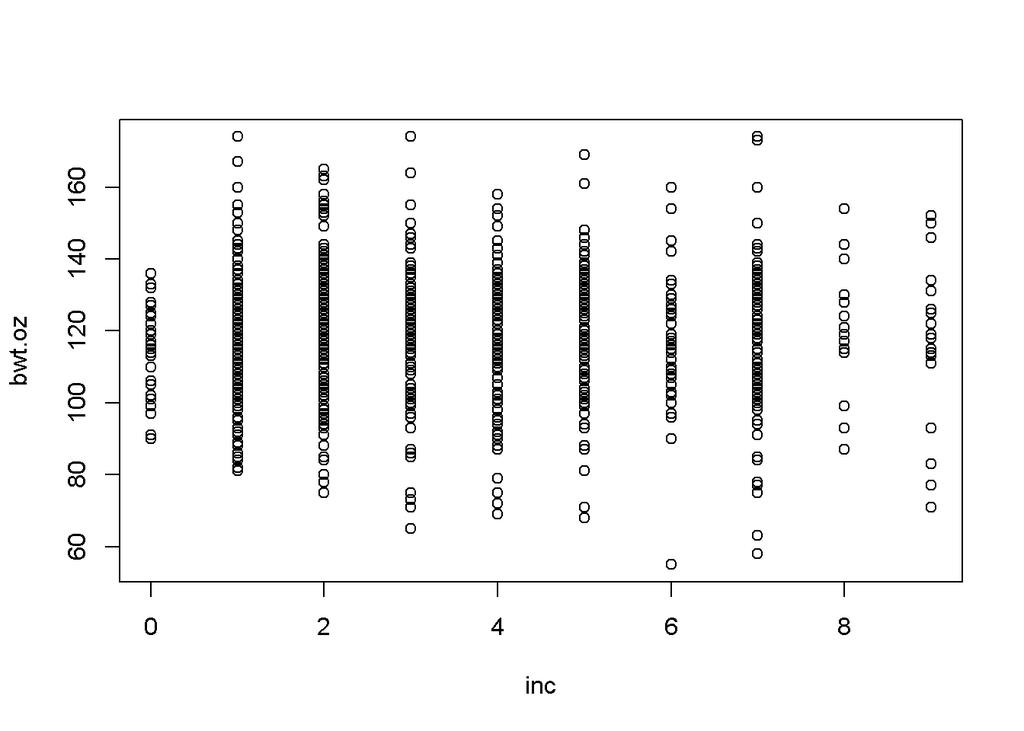

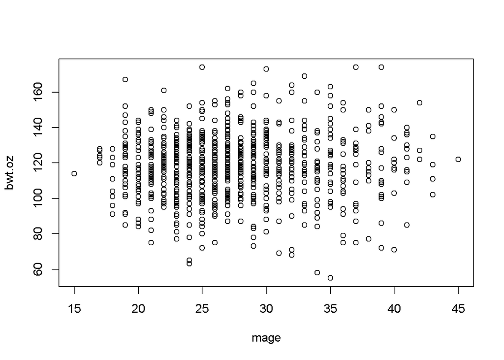

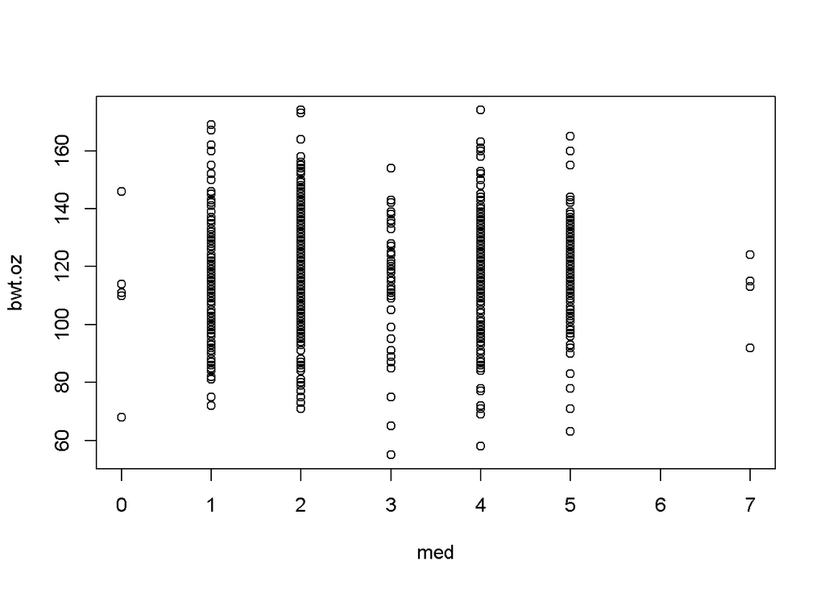

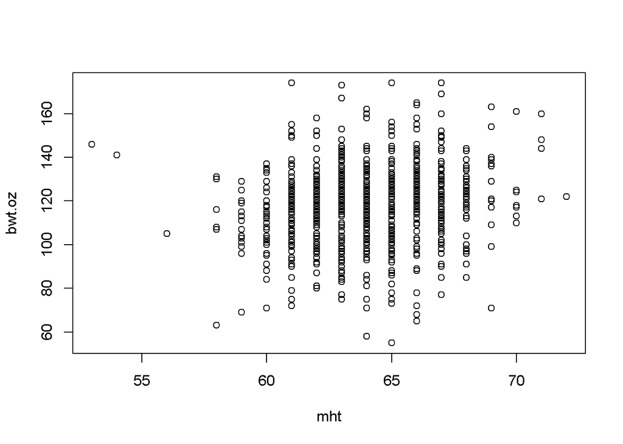

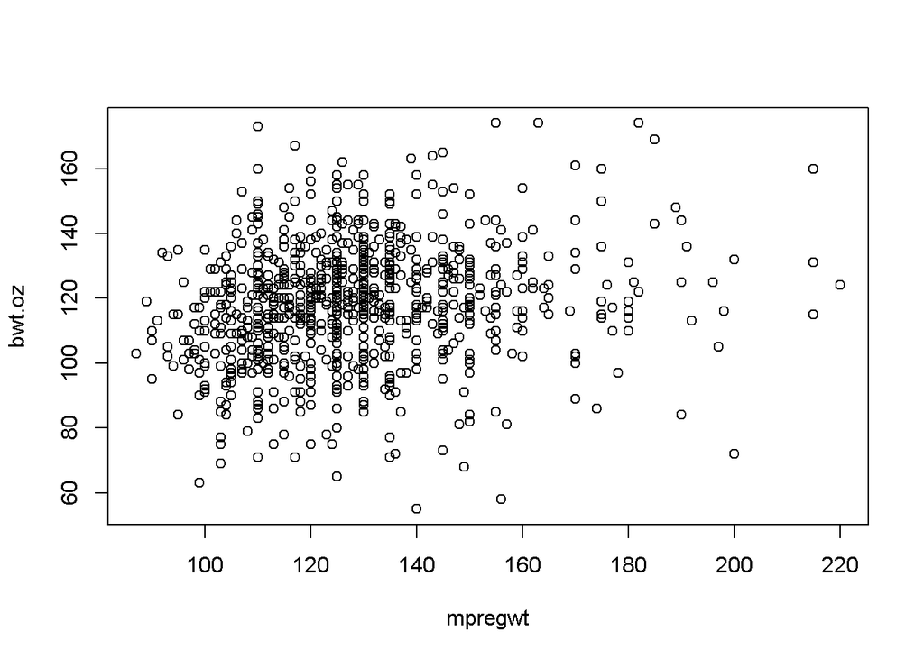

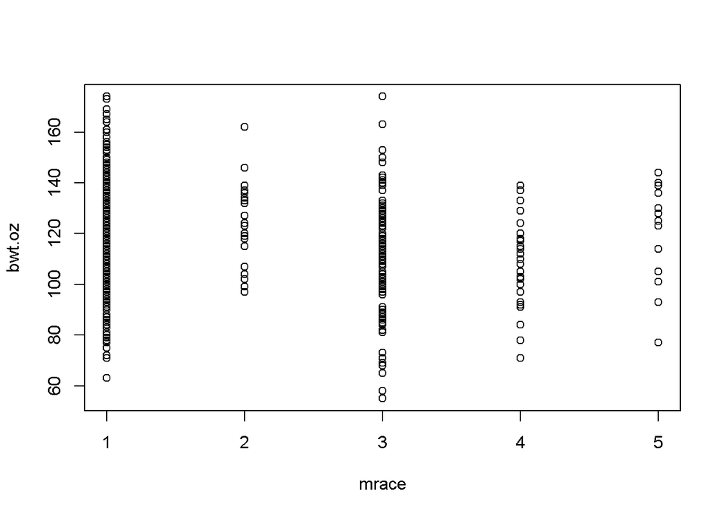

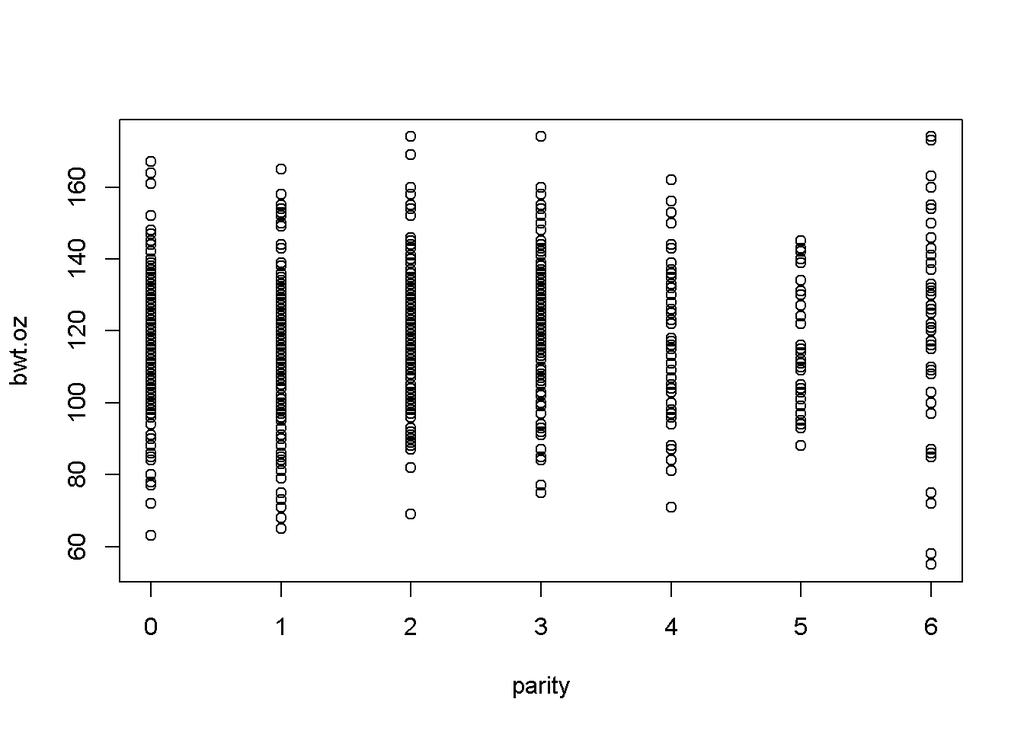

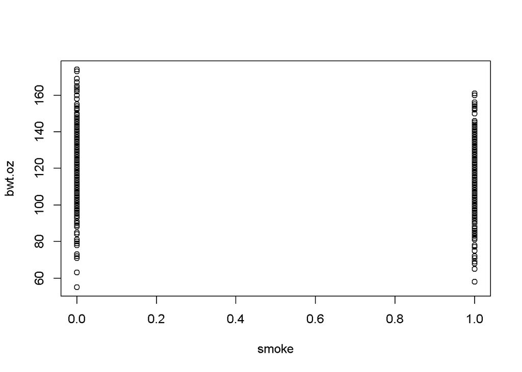

```r
#collapsing all white races to one
smoking$mrace[smoking$mrace== 0] <- 1  # white
smoking$mrace[smoking$mrace== 1] <- 1  # white
smoking$mrace[smoking$mrace== 2] <- 1  # white
smoking$mrace[smoking$mrace== 3] <- 1  # white
smoking$mrace[smoking$mrace== 4] <- 1  # white
smoking$mrace[smoking$mrace== 5] <- 1  # white
smoking$mrace[smoking$mrace== 6] <- 2  # Mexican
smoking$mrace[smoking$mrace== 7] <- 3  # Black
smoking$mrace[smoking$mrace== 8] <- 4  # Asian
smoking$mrace[smoking$mrace== 9] <- 5  # Mix
smoking$mrace[smoking$mrace== 99] <- NA

#collapsing all pervious pregnancies to 1-5 and 6+
smoking$parity[smoking$parity== 0] <- 0 # No previous Child
smoking$parity[smoking$parity== 1] <- 1 # 1 Prevous Child
smoking$parity[smoking$parity== 2] <- 2 # 1 Prevous Child
smoking$parity[smoking$parity== 3] <- 3 # 1 Prevous Child
smoking$parity[smoking$parity== 4] <- 4 # 1 Prevous Child
smoking$parity[smoking$parity== 5] <- 5 # 5 Prevous Child
smoking$parity[smoking$parity== 6] <- 6 # 6 Prevous Child
smoking$parity[smoking$parity== 7] <- 6 # 6 Prevous Child
smoking$parity[smoking$parity== 8] <- 6 # 6 Prevous Child
smoking$parity[smoking$parity== 9] <- 6 # 6 Prevous Child
smoking$parity[smoking$parity== 10] <- 6 # 6 Prevous Child
smoking$parity[smoking$parity== 11] <- 6 # 6 Prevous Child

# explority plots to see if there is anything noticable prior to transformation or
# regression modeling
plot(bwt.oz ~ inc + mage + med + mht + mpregwt +
       mrace + parity + smoke, data = smoking, ask = T)
```

Next, I collapsed all misc. white races into one singular set. This was suggested in the problem descriptions and allows me to better analyze the data in question 2 as stated above.

Also after looking at the plots for ‘parity,’ I decided to group all pregnancies/births greater than or equal to 6 as one set, with all others remaining to their own grouping.

Looking through these initial plots, no major malformations or abnormalities present themselves. The data looks relatively linear as it is so I am not inclined to do any transformations of the data.

```r
#regression model
birthModel <- lm(bwt.oz ~ as.factor(smoke) * as.factor(mrace) + mht + mpregwt + as.factor(med) * inc + mage * as.factor(parity), data = smoking)
# looking at the model
summary(birthModel) # R-squared is 0.1842 however smoking p value is 3.36e-12
```

```
##
## Call:
## lm(formula = bwt.oz ~ as.factor(smoke) * as.factor(mrace) + mht +
##     mpregwt + as.factor(med) * inc + mage * as.factor(parity),
##     data = smoking)
##
## Residuals:
##     Min      1Q  Median      3Q     Max
## -63.045 -10.072  -0.016  10.312  53.786
##
## Coefficients:
##                                      Estimate Std. Error t value Pr(>|t|)
## (Intercept)                          50.20632   22.23434   2.258 0.024201
## as.factor(smoke)1                    -9.68211    1.37008  -7.067 3.36e-12
## as.factor(mrace)2                     1.98966    4.04744   0.492 0.623142
## as.factor(mrace)3                    -9.72016    2.10425  -4.619 4.46e-06
## as.factor(mrace)4                    -5.91256    3.61697  -1.635 0.102496
## as.factor(mrace)5                    -0.59299    5.00817  -0.118 0.905775
## mht                                   0.92955    0.27046   3.437 0.000618
## mpregwt                               0.11195    0.03287   3.406 0.000691
## as.factor(med)1                      -4.39358   13.93835  -0.315 0.752678
## as.factor(med)2                       2.42128   13.76012   0.176 0.860365
## as.factor(med)3                      -0.53655   14.63006  -0.037 0.970753
## as.factor(med)4                       1.29356   13.85372   0.093 0.925630
## as.factor(med)5                       8.18719   13.91117   0.589 0.556334
## as.factor(med)7                     -12.17229   24.04534  -0.506 0.612835
## inc                                  -3.26073    4.68183  -0.696 0.486332
## mage                                 -0.14482    0.26637  -0.544 0.586792
## as.factor(parity)1                    1.45940    8.95756   0.163 0.870618
## as.factor(parity)2                    7.45324    9.31489   0.800 0.423857
## as.factor(parity)3                    3.87162   10.70626   0.362 0.717727
## as.factor(parity)4                    1.51864   14.96890   0.101 0.919215
## as.factor(parity)5                   -9.09370   19.21431  -0.473 0.636140
## as.factor(parity)6                   25.31988   22.90862   1.105 0.269369
## as.factor(smoke)1:as.factor(mrace)2  15.31586    8.24946   1.857 0.063723
## as.factor(smoke)1:as.factor(mrace)3   2.48622    2.96474   0.839 0.401937
## as.factor(smoke)1:as.factor(mrace)4  -7.52693    6.67823  -1.127 0.260032
## as.factor(smoke)1:as.factor(mrace)5 -10.46181   11.09657  -0.943 0.346059
## as.factor(med)1:inc                   4.63346    4.77262   0.971 0.331910
## as.factor(med)2:inc                   3.06410    4.71008   0.651 0.515523
```

[output cut: 40 more lines]

```
## as.factor(med)4:inc
## as.factor(med)5:inc
## as.factor(med)7:inc
## mage:as.factor(parity)1
## mage:as.factor(parity)2
## mage:as.factor(parity)3
## mage:as.factor(parity)4
## mage:as.factor(parity)5
## mage:as.factor(parity)6
## ---
## Signif. codes:  0 '***' 0.001 '**' 0.01 '*' 0.05 '.' 0.1 ' ' 1
##
## Residual standard error: 16.66 on 831 degrees of freedom
## Multiple R-squared:  0.1842, Adjusted R-squared:  0.1479
## F-statistic: 5.072 on 37 and 831 DF,  p-value: < 2.2e-16
```

After no apparent abnormalities or errors came up from looking at the plots, I decided not to use any transformations as I do not believe they well help. After minimalizing the different white races into one, I looked at the other variables to see if they needed to be factorized. I made all non-continious variables (smoke, mrace, med, and parity) factors for the model. This allows a much more straight interpreation from the model for prediction purposes.

With the model I decided to use interaction between education and income, as they had a strong correlation between to two variables. We’ve seen in other data sets that more education tends to lead to better income.

Next I decided to do an interaction between age and parity. The reasoning behind this is, logicallically thinking, child birth is a process that takes 40 weeks, therefore a woman who has multiple children will have to age approximately a year at bare minimum to do so.

```r
raceBirthModel <- lm(bwt.oz ~ as.factor(smoke) + as.factor(mrace) + mht + mpregwt +
                       as.factor(med) * inc + mage * as.factor(parity), data = smoking)

summary(raceBirthModel)
```

```
##
## Call:
## lm(formula = bwt.oz ~ as.factor(smoke) + as.factor(mrace) + mht +
##     mpregwt + as.factor(med) * inc + mage * as.factor(parity),
##     data = smoking)
##
## Residuals:
##     Min      1Q  Median      3Q     Max
## -63.633  -9.857  -0.101  10.072  52.561
##
## Coefficients:
##                          Estimate Std. Error t value Pr(>|t|)
## (Intercept)              54.54547   22.17072   2.460  0.01409 *
## as.factor(smoke)1        -9.24466    1.18836  -7.779 2.15e-14 ***
## as.factor(mrace)2         5.57617    3.55454   1.569  0.11709
## as.factor(mrace)3        -8.64673    1.59280  -5.429 7.45e-08 ***
## as.factor(mrace)4        -7.95792    3.11978  -2.551  0.01093 *
## as.factor(mrace)5        -2.61489    4.47145  -0.585  0.55884
## mht                       0.87293    0.26936   3.241  0.00124 **
## mpregwt                   0.11085    0.03287   3.372  0.00078 ***
## as.factor(med)1          -4.53037   13.94662  -0.325  0.74539
## as.factor(med)2           1.61054   13.76319   0.117  0.90687
## as.factor(med)3          -0.82582   14.63329  -0.056  0.95501
## as.factor(med)4           0.49514   13.85887   0.036  0.97151
## as.factor(med)5           7.73256   13.91188   0.556  0.57848
## as.factor(med)7         -15.59573   23.98426  -0.650  0.51571
## inc                      -2.54235    4.67708  -0.544  0.58688
## mage                     -0.15104    0.26632  -0.567  0.57076
## as.factor(parity)1        1.18145    8.96037   0.132  0.89513
## as.factor(parity)2        8.18392    9.31747   0.878  0.38001
## as.factor(parity)3        3.01323   10.70420   0.281  0.77840
## as.factor(parity)4        3.61787   14.96348   0.242  0.80901
## as.factor(parity)5      -12.67905   18.86915  -0.672  0.50180
## as.factor(parity)6       22.59520   22.89887   0.987  0.32406
## as.factor(med)1:inc       3.83141    4.76462   0.804  0.42155
## as.factor(med)2:inc       2.36700    4.70625   0.503  0.61513
## as.factor(med)3:inc       2.47809    4.80730   0.515  0.60635
## as.factor(med)4:inc       2.78295    4.71926   0.590  0.55555
## as.factor(med)5:inc       1.03975    4.70898   0.221  0.82530
## as.factor(med)7:inc       5.03245   11.22489   0.448  0.65403
## mage:as.factor(parity)1   0.03910    0.35690   0.110  0.91278
## mage:as.factor(parity)2  -0.12133    0.35538  -0.341  0.73288
## mage:as.factor(parity)3   0.12819    0.38853   0.330  0.74153
## mage:as.factor(parity)4   0.07845    0.50269   0.156  0.87602
## mage:as.factor(parity)5   0.52490    0.59497   0.882  0.37791
## mage:as.factor(parity)6  -0.44635    0.68489  -0.652  0.51476
## ---
## Signif. codes:  0 '***' 0.001 '**' 0.01 '*' 0.05 '.' 0.1 ' ' 1
##
## Residual standard error: 16.69 on 835 degrees of freedom
## Multiple R-squared:  0.1779, Adjusted R-squared:  0.1454
## F-statistic: 5.475 on 33 and 835 DF,  p-value: < 2.2e-16
```

```r
anova(birthModel, raceBirthModel)
```

```
## Analysis of Variance Table
##
## Model 1: bwt.oz ~ as.factor(smoke) * as.factor(mrace) + mht + mpregwt +
##     as.factor(med) * inc + mage * as.factor(parity)
## Model 2: bwt.oz ~ as.factor(smoke) + as.factor(mrace) + mht + mpregwt +
##     as.factor(med) * inc + mage * as.factor(parity)
##   Res.Df    RSS Df Sum of Sq      F Pr(>F)
## 1    831 230717
## 2    835 232508 -4   -1790.7 1.6125 0.1691
```

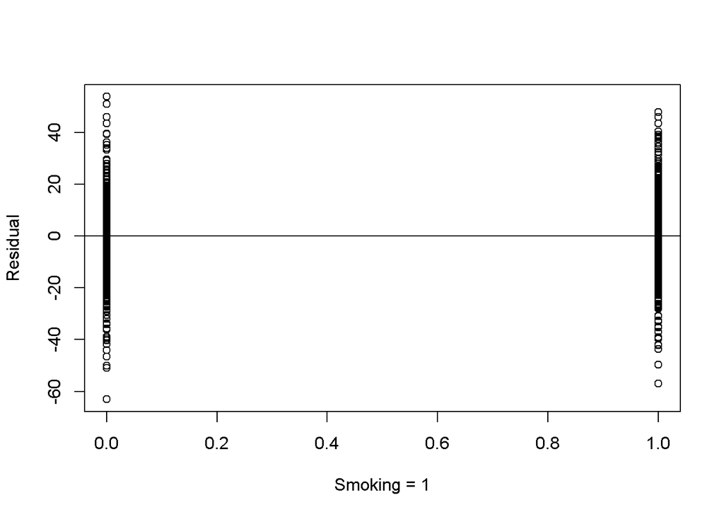

```r
#plot residuals to make adjustments

# smoking
plot(y= birthModel$residual, x = smoking$smoke, xlab = "Smoking = 1", ylab = "Residual")
abline(0,0)
```

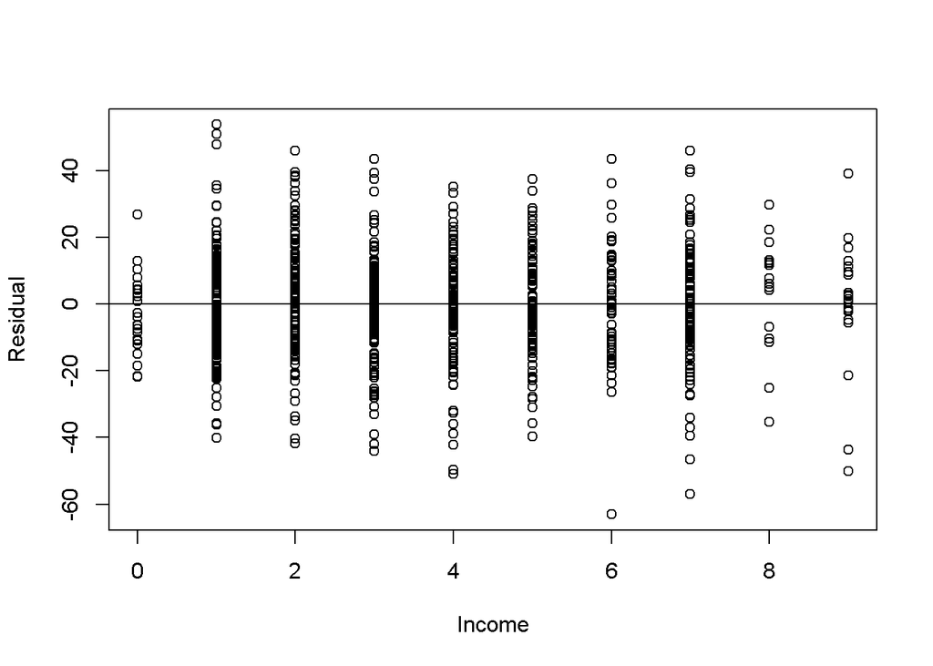

```r
# income
plot(y= birthModel$residual, x = smoking$inc, xlab = "Income", ylab = "Residual")
abline(0,0)
```

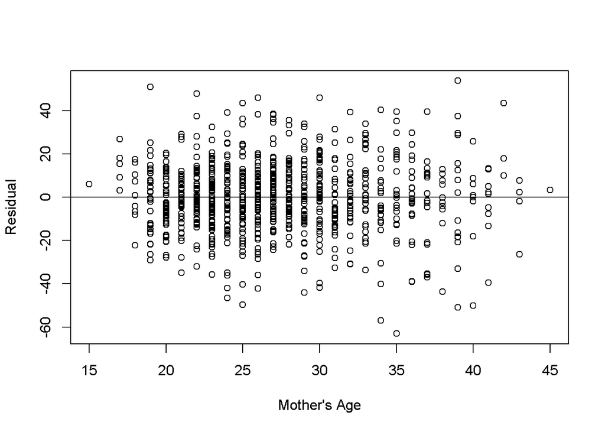

```r
# mother's age
plot(y= birthModel$residual, x = smoking$mage, xlab = "Mother's Age", ylab = "Residual")
abline(0,0)
```

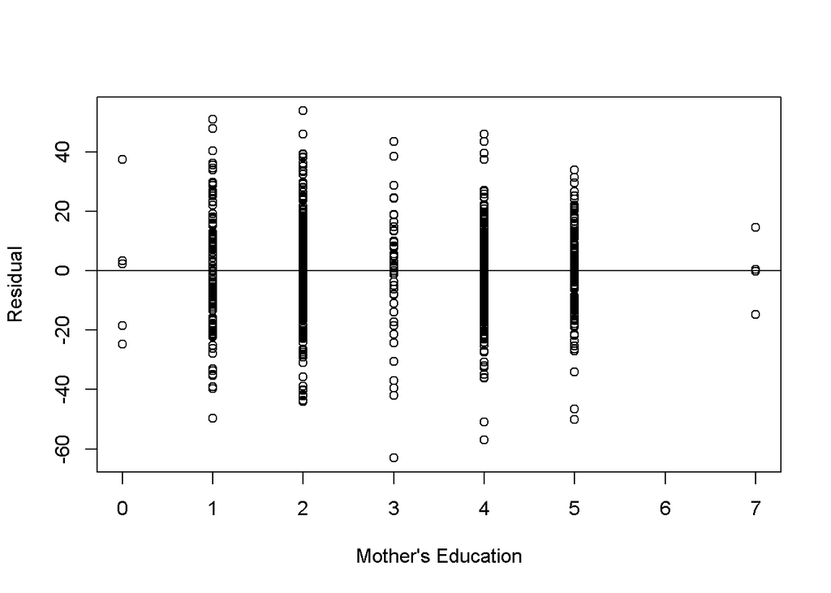

```r
#mother's education
plot(y= birthModel$residual, x = smoking$med, xlab = "Mother's Education", ylab = "Residual")
abline(0,0)
```

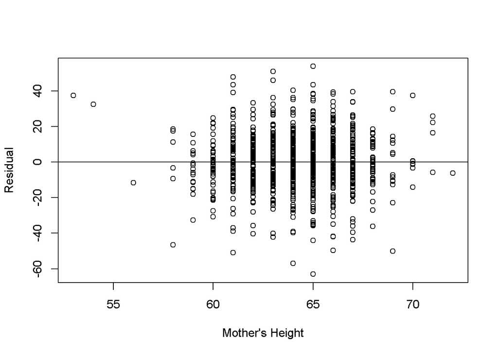

```r
# mother's height
plot(y= birthModel$residual, x = smoking$mht, xlab = "Mother's Height", ylab = "Residual")
abline(0,0)
```

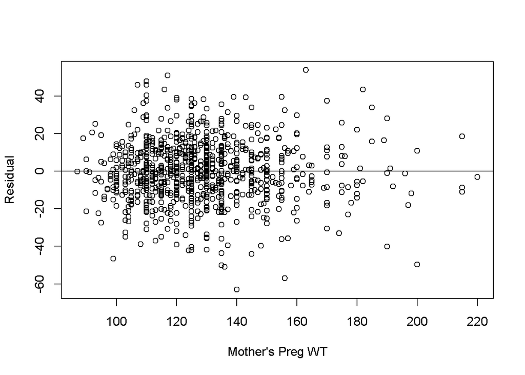

```r
# mother's Pregnancy weight
plot(y= birthModel$residual, x = smoking$mpregwt, xlab = "Mother's Preg WT", ylab = "Residual")
abline(0,0)
```

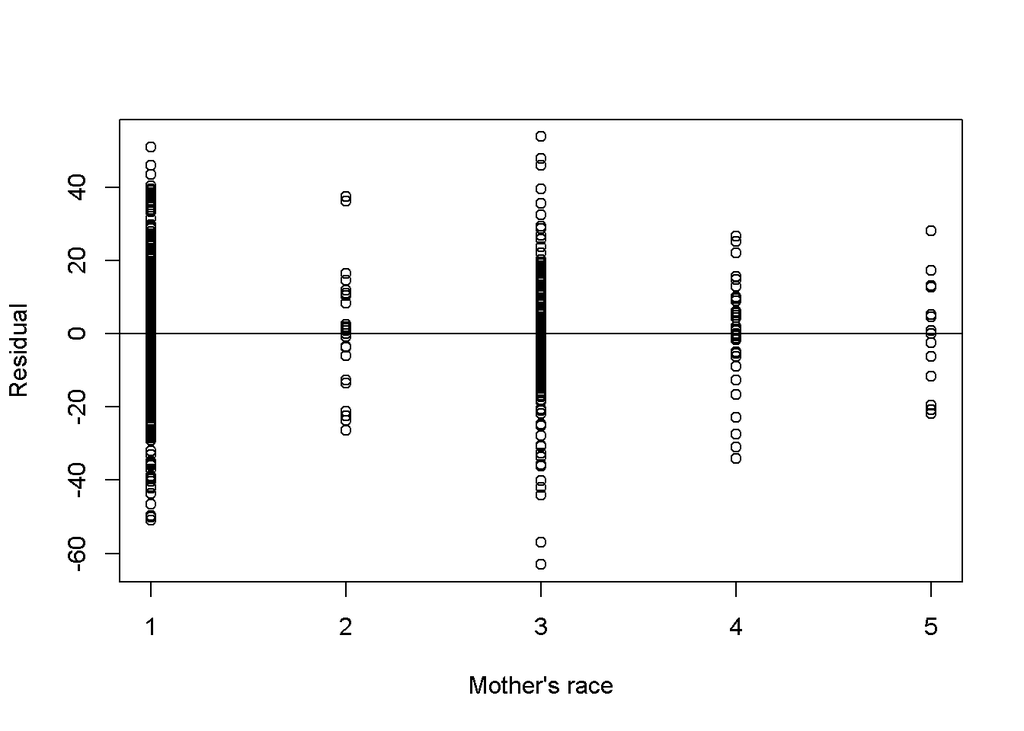

```r
# mother's race
plot(y= birthModel$residual, x = smoking$mrace, xlab = "Mother's race", ylab = "Residual")
abline(0,0)
```

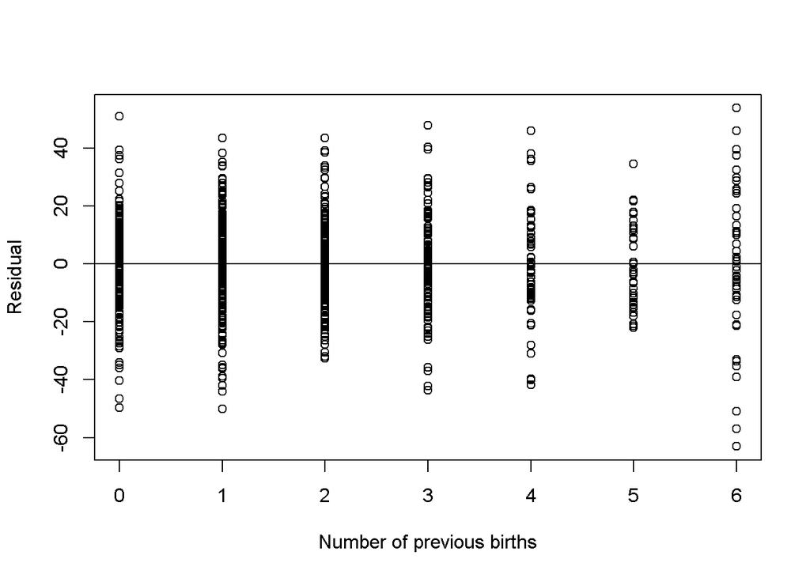

```r
# mother's parity (number of previous births)
plot(y= birthModel$residual, x = smoking$parity, xlab = "Number of previous births", ylab = "Residual")
abline(0,0)
```

```r
confint(birthModel, level = 0.95)
```

```
##                                            2.5 %     97.5 %
## (Intercept)                           6.56424293 93.8483926
## as.factor(smoke)1                   -12.37133808 -6.9928917
## as.factor(mrace)2                    -5.95474875  9.9340764
## as.factor(mrace)3                   -13.85042518 -5.5899016
## as.factor(mrace)4                   -13.01202490  1.1869000
## as.factor(mrace)5                   -10.42313633  9.2371485
## mht                                   0.39868814  1.4604119
## mpregwt                               0.04743104  0.1764608
## as.factor(med)1                     -31.75209229 22.9649415
## as.factor(med)2                     -24.58740139 29.4299713
## as.factor(med)3                     -29.25277349 28.1796755
## as.factor(med)4                     -25.89883698 28.4859502
## as.factor(med)5                     -19.11797603 35.4923559
## as.factor(med)7                     -59.36903357 35.0244522
## inc                                 -12.45033044  5.9288707
## mage                                 -0.66765087  0.3780041
## as.factor(parity)1                  -16.12270767 19.0415015
## as.factor(parity)2                  -10.83023054 25.7367181
## as.factor(parity)3                  -17.14287900 24.8861111
## as.factor(parity)4                  -27.86264728 30.8999344
## as.factor(parity)5                  -46.80797207 28.6205799
## as.factor(parity)6                  -19.64568858 70.2854474
## as.factor(smoke)1:as.factor(mrace)2  -0.87636709 31.5080780
## as.factor(smoke)1:as.factor(mrace)3  -3.33304130  8.3054900
## as.factor(smoke)1:as.factor(mrace)4 -20.63511249  5.5812525
## as.factor(smoke)1:as.factor(mrace)5 -32.24240428 11.3187774
## as.factor(med)1:inc                  -4.73435668 14.0012695
## as.factor(med)2:inc                  -6.18095782 12.3091541
## as.factor(med)3:inc                  -6.11362399 12.7854405
## as.factor(med)4:inc                  -5.82314537 12.7144360
## as.factor(med)5:inc                  -7.47318099 11.0314882
## as.factor(med)7:inc                 -17.33928713 26.6839073
## mage:as.factor(parity)1              -0.67054761  0.7302449
## mage:as.factor(parity)2              -0.79494101  0.6007130
## mage:as.factor(parity)3              -0.66763299  0.8586119
## mage:as.factor(parity)4              -0.83944657  1.1352701
## mage:as.factor(parity)5              -0.76329636  1.6125688
## mage:as.factor(parity)6              -1.88020918  0.8116614
```

Looking through the residual plots of all of the valuables, we can see that the model we used is accurate as the points on the plots are evenly distributed on both sides of the (0,0) line.

On to the questions: **1)** Do mothers who smoke tend to give birth to babies with lower weights than mothers who do not smoke? What is a likely range for the difference in birth weights for smokers and non-smokers?

**2)** Is there any evidence that the association between smoking and birth weight differs by mother’s race? If so, characterize those differences.

**3)** Are there other interesting associations with birth weight that are worth mentioning? So, the question is asking about the remaining predictor variables in the model and their associations with birth weight.